# 데이터 시각화

이모지(emoji): 코로나19

[Tidyverse Korea](https://web.facebook.com/groups/tidyverse/)

2020-06-04

# 1 코로나19 사망자수 💀

[`coronavirus`](https://github.com/RamiKrispin/coronavirus) 데이터 팩키지에서 코로나19로 인한 국가별 사망자 데이터를 정제하여 상위 10국을 현재 2020-06-04 기준 준비한다.

```r
library(tidyverse)
library(coronavirus)

covid_death <- coronavirus %>%
  filter(type == "death") %>%
  group_by(country) %>%
  summarise(cases = sum(cases)) %>%
  ungroup() %>%
  top_n(10, wt=cases) %>%
  arrange(desc(cases))

covid_death
```

```
# A tibble: 10 x 2
   country        cases
   <chr>          <int>
 1 US             82356
 2 United Kingdom 32769
 3 Italy          30911
 4 France         26994
 5 Spain          26920
 6 Brazil         12461
 7 Belgium         8761
 8 Germany         7738
 9 Iran            6733
10 Netherlands     5529
```

# 2 이미지 데이터 🖼 [^1]

이모지(絵文字 / emoji)는 일본의 휴대전화 문자 메시지에서 시작되어 지금은 대부분의 스마트폰에 사용되는 그림 문자로 역사를 되돌리는 현대판 이집트 상형문자로 이해되기도 한다. `tidyverse` R진영에서 이를 구현한 것이 [`emo`](https://github.com/hadley/emo) 팩키지로 R마크다운 문서에서 쉽게 이모지를 구현할 수 있다.

[`emojifont`](https://cran.r-project.org/web/packages/emojifont/vignettes/emojifont.html) 팩키지가 있다고 하지만, “Apple Color Emoji”을 사용하지 않고 있다고 한다. 무엇보다 해들리 위컴이 [`emo`](https://github.com/hadley/emo) 팩키지를 직접 만들었다는 점에서 의미가 크다.

[`emo`](https://github.com/hadley/emo), [`ggtext`](https://github.com/wilkelab/ggtext) 팩키지를 장착한 ggplot에 이미지를 구현하는 장단점은 다음과 같다.

- 장점
  - 실제로 동작함.
  - SVG를 사용할 필요 없음.
  - 미리보기가 미려하게 출력됨.
- 단점
  - `ggtext`가 아직 개발중에 있음.
  - 웹스크래핑을 해야함.
  - 화면에 뿌려줄 때 인터넷 연결이 필요함
  - `size`를 담긴 변수를 `ggplot`으로 활용할 수 없음.

## 2.1 국기 이모지 [^2]

```r
# 빠른 국가명 추출
emoji_names <- names(emo::ji_name) %>% str_to_lower()

covid_death_country <- covid_death %>%
  pull(country) %>%
  str_to_lower()

# for(i in seq_along(covid_death_country)) {
#   cat(emoji_names[str_detect(emoji_names, covid_death_country[i])], "\n")
# }

# emoji_names[str_detect(emoji_names, "us")]

corona_top_country <- c("us","uk","italy","france","spain","brazil","belgium","germany","iran","netherlands")

covid_death_df <- covid_death %>%
  mutate(country_emoji = corona_top_country) %>%
  mutate(emoji = map_chr(country_emoji, emo::ji))

covid_death_df
```

```
# A tibble: 10 x 4
   country        cases country_emoji emoji
   <chr>          <int> <chr>         <chr>
 1 US             82356 us            🇺🇸
 2 United Kingdom 32769 uk            🇬🇧
 3 Italy          30911 italy         🇮🇹
 4 France         26994 france        🇫🇷
 5 Spain          26920 spain         🇪🇸
 6 Brazil         12461 brazil        🇧🇷
 7 Belgium         8761 belgium       🇧🇪
 8 Germany         7738 germany       🇩🇪
 9 Iran            6733 iran          🇮🇷
10 Netherlands     5529 netherlands   🇳🇱
```

`ggplot`으로 국기를 출력하기 위해서는 웹스크래핑을 통해 https://emojipedia.org/emoji/ 웹사이트에서 이미지 링크를 가져온다.

```r
library(rvest)

emoji_to_link <- function(x) {
  paste0("https://emojipedia.org/emoji/",x) %>%
    read_html() %>%
    html_nodes("tr td a") %>%
    .[1] %>%
    html_attr("href") %>%
    paste0("https://emojipedia.org/", .) %>%
    read_html() %>%
    html_node('div[class="vendor-image"] img') %>%
    html_attr("src")
}

link_to_img <- function(x, size = 25) {
  paste0("<img src='", x, "' width='", size, "'/>")
}

covid_death_df <- covid_death_df %>%
  mutate(url = map_chr(emoji, slowly(~emoji_to_link(.x), rate_delay(0.5))),
         label = link_to_img(url))

covid_death_df
```

```
# A tibble: 10 x 6
   country   cases country_emoji emoji url                  label
   <chr>     <int> <chr>         <chr> <chr>                <chr>
 1 US        82356 us            🇺🇸    https://emojipedia-… <img src='https://e…
 2 United K… 32769 uk            🇬🇧    https://emojipedia-… <img src='https://e…
 3 Italy     30911 italy         🇮🇹    https://emojipedia-… <img src='https://e…
 4 France    26994 france        🇫🇷    https://emojipedia-… <img src='https://e…
 5 Spain     26920 spain         🇪🇸    https://emojipedia-… <img src='https://e…
 6 Brazil    12461 brazil        🇧🇷    https://emojipedia-… <img src='https://e…
 7 Belgium    8761 belgium       🇧🇪    https://emojipedia-… <img src='https://e…
 8 Germany    7738 germany       🇩🇪    https://emojipedia-… <img src='https://e…
 9 Iran       6733 iran          🇮🇷    https://emojipedia-… <img src='https://e…
10 Netherla…  5529 netherlands   🇳🇱    https://emojipedia-… <img src='https://e…
```

# 3 시각화

앞서 준비한 각 국가를 표상하는 국기에 해당되는 이모지의 `.png`파일에 대한 웹 주소를 참조하고 이를 `ggtext` 팩키지 `geom_richtext()`함수로 시각화한다. 중국이 상위 10개국에 들지 않는 것이 눈에 띄네요!!!

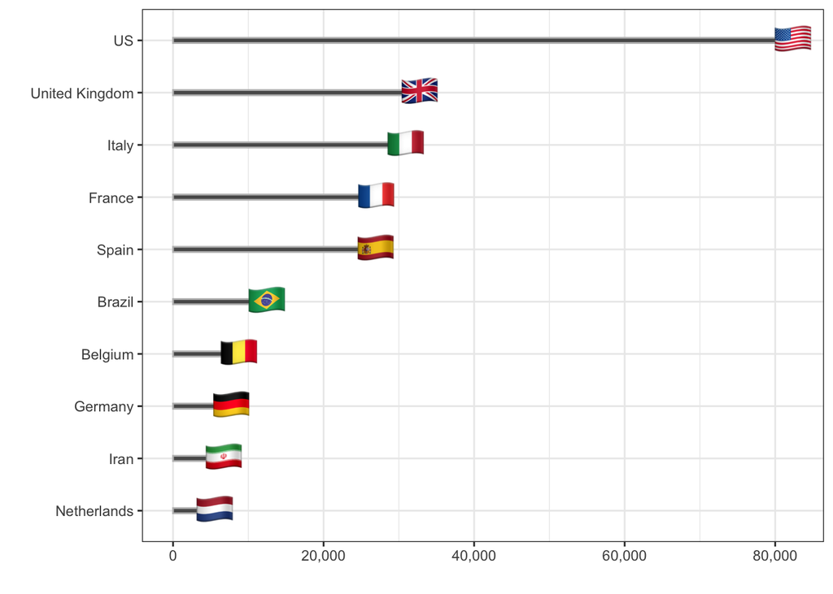

```r
library(ggtext)

covid_death_df %>%
  mutate(country = fct_reorder(country, cases)) %>%
  ggplot(aes(x=country, y=cases, label = label)) +
    geom_col(width=0.1, color="gray") +
    geom_point() +
    coord_flip() +
    labs(x="", y="") +
    theme_bw() +
    geom_richtext(aes(y = cases), fill = NA, label.color = NA,
                label.padding = grid::unit(rep(0, 4), "pt") ) +
    scale_y_continuous(labels = scales::comma)
```

[^1]: [Emil Hvitfelldt, (May 1, 2020), “Real Emojis in ggplot2”](https://www.hvitfeldt.me/blog/real-emojis-in-ggplot2/)
[^2]: [stackoverflow, “United Kingdom emoji with `emo::ji`”](https://stackoverflow.com/questions/54120268/united-kingdom-emoji-with-emoji)